# Portfolio Selection: QAOA + VQE Hybrid (25-Qubit Capacity)

**Extension of:** `paper_code_26_apr.ipynb` **Authors:** Vandna Chaturvedi, Vivek Nainwal, Anoop Kumar — CDAC Hyderabad

## Pipeline Architecture

```
N assets
    │
    ▼
[STEP 1] QAOA (N qubits, shot-based)
    │  → binary bitstring → K selected assets
    ▼
[STEP 2] VQE  (K qubits only, statevector exact)
    │  → |sin(θ)| continuous weights on K assets
    ▼
[STEP 3] DRO Stress Test (classical)
    │  → adversarial perturbations → robust weights
    ▼
[STEP 4] CMA-ES Polish (classical, optional)
    │  → fine-tuned final weights
    ▼
Final Portfolio
```

| Step | Algorithm | Solves | Qubits |
| --- | --- | --- | --- |
| 1 | QAOA (p layers) | **Which** K assets to pick (binary) | N=25 |
| 2 | VQE TwoLocal | **How much** weight per selected asset | K≤7 |
| 3 | DRO-CVaR | Worst-case robustness | — |
| 4 | CMA-ES | Continuous polish | — |

**Key innovation over paper_code_26_apr:** QAOA handles the binary selection (its native problem); VQE handles continuous allocation on only K qubits (faster, exact).

## Cell 1 — Imports

```python
%matplotlib inline
import os, sys, warnings, time
import numpy as np
import pandas as pd
import matplotlib.pyplot as plt
import matplotlib.patches as mpatches
from matplotlib.gridspec import GridSpec
from collections import OrderedDict
from scipy.optimize import minimize as sp_minimize, dual_annealing
from scipy.stats import norm

try:
    import cma as _cma; _HAS_CMA = True
except ImportError:
    _HAS_CMA = False
    warnings.warn("cma not installed — CMA-ES step will be skipped")

from qiskit.circuit.library import TwoLocal
from qiskit import QuantumCircuit
from qiskit.circuit import Parameter
from qiskit.quantum_info import SparsePauliOp
from qiskit_aer.primitives import Sampler as AerSampler, Estimator as AerEstimator
from qiskit.primitives import StatevectorEstimator

warnings.filterwarnings("ignore")
OUT_DIR = os.getcwd()

STEP_COLORS = {
    "QAOA":  "#2196F3",
    "VQE":   "#9C27B0",
    "DRO":   "#F44336",
    "CMA":   "#4CAF50",
    "Final": "#FF9800",
}

def _hms(s):
    m, s = divmod(int(s), 60)
    return f"{m}m {s:02d}s" if m else f"{s}s"

def build_qaoa_circuit(H, p):
    """Manual QAOA circuit — avoids QAOAAnsatz complex-coefficient library bug.
    Returns (circuit_with_measurements, ordered_parameter_list).
    Parameters: [γ_0..γ_{p-1}, β_0..β_{p-1}]  (total 2p).
    """
    n      = H.num_qubits
    gammas = [Parameter(f'g{i}') for i in range(p)]
    betas  = [Parameter(f'b{i}') for i in range(p)]
    qc     = QuantumCircuit(n, n)
    qc.h(range(n))                                    # |+>^n initial state
    for layer in range(p):
        g, b = gammas[layer], betas[layer]
        # Cost unitary — loop over Pauli terms
        for pauli_str, coeff in zip([str(pp) for pp in H.paulis], H.coeffs):
            c = float(np.real(coeff))
            if abs(c) < 1e-10: continue
            zq = [i for i,op in enumerate(reversed(pauli_str)) if op=='Z']
            angle = g * float(2.0 * c)   # Parameter * scalar (scalar computed first)
            if   len(zq)==1: qc.rz(angle, zq[0])
            elif len(zq)==2:
                qc.cx(zq[0],zq[1]); qc.rz(angle,zq[1]); qc.cx(zq[0],zq[1])
            # I and higher-order terms skipped (no X/Y in Ising H)
        # Mixer unitary — independent X rotations
        for i in range(n): qc.rx(b * 2.0, i)
    qc.measure(range(n), range(n))
    return qc, gammas+betas

print("Imports OK")
print(f"  CMA-ES available : {_HAS_CMA}")
```

```
Imports OK
  CMA-ES available : False
```

## Cell 2 — Configuration

> **CPU default:** `N_ASSETS=15` (15 qubits QAOA via shots, 5-qubit VQE exact). **H100 GPU:** set `N_ASSETS=25`, `USE_GPU=True`, `QAOA_SHOTS=8192`.

```python
ALL_TICKERS = [
    "AAPL","MSFT","GOOGL","AMZN","NVDA",
    "META","TSLA","JPM", "JNJ", "V",
    "UNH", "MA",  "HD",  "PG",  "BAC",
    "XOM", "CVX", "LLY", "ABBV","MRK",
    "KO",  "PEP", "COST","WMT", "NFLX",
]

N_ASSETS     = 15       # set to 25 for H100
USE_GPU      = False    # set True to enable cuStateVec
BUDGET_K     = 5        # QAOA selects this many assets
TRADING_DAYS = 252

Q             = 0.5
ALPHA_LEVELS  = [0.95, 0.99, 0.999]
ALPHA_WEIGHTS = [0.3,  0.4,  0.3]
CVAR_BETA     = 0.1
DRO_SAMPLES   = 20
DRO_RADIUS    = 0.08

QAOA_P        = 2
QAOA_SHOTS    = 2048
QAOA_MAXITER  = 150

VQE_REPS      = 2
VQE_MAXITER   = 120
PENALTY_B     = 100.0

CMAES_SIGMA0  = 0.3
CMAES_MAXITER = 200

TICKERS = ALL_TICKERS[:N_ASSETS]

print(f"Universe  : {N_ASSETS} assets")
print(f"Budget K  : {BUDGET_K}  (QAOA selects {BUDGET_K} of {N_ASSETS})")
print(f"QAOA      : p={QAOA_P}, shots={QAOA_SHOTS} — no 2^N memory needed")
print(f"VQE       : {BUDGET_K} qubits, exact statevector (2^{BUDGET_K}={2**BUDGET_K} amps)")
print(f"GPU mode  : {USE_GPU}")
```

```
Universe  : 15 assets
Budget K  : 5  (QAOA selects 5 of 15)
QAOA      : p=2, shots=2048 — no 2^N memory needed
VQE       : 5 qubits, exact statevector (2^5=32 amps)
GPU mode  : False
```

## Cell 3 — Data Loading

```
[yfinance] 500 days x 15 tickers
```

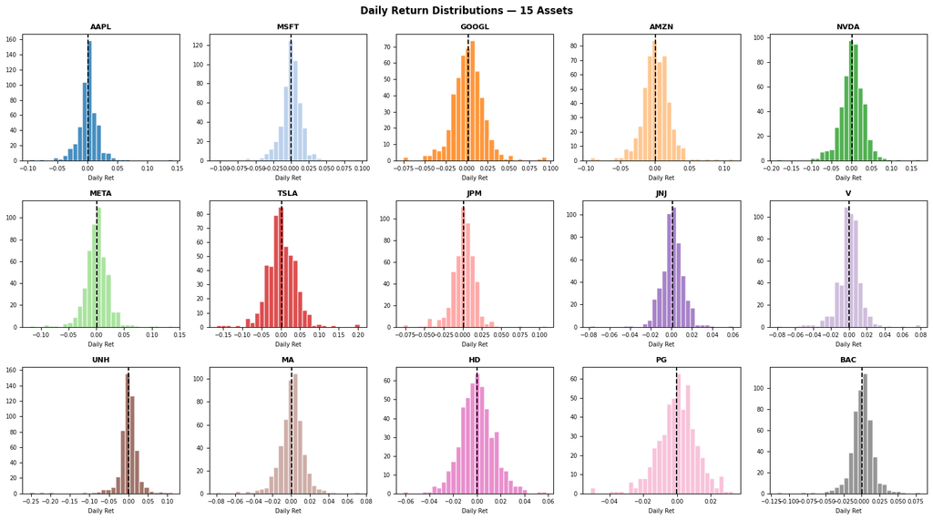

```
Top-5 Ann. Return : [(0.42923617302356104, 'GOOGL'), (0.418994549982193, 'NVDA'), (0.4070147623502783, 'TSLA'), (0.27127858047555464, 'JPM'), (0.23758690269183316, 'JNJ')]
Top-5 Ann. Sharpe : [(1.4333019235714302, 'GOOGL'), (1.3357675402992006, 'JNJ'), (1.078669385233724, 'JPM'), (0.8632503667994348, 'NVDA'), (0.8349220566175719, 'AAPL')]
```

```python
def _synthetic(tickers, n_days=504, seed=42):
    rng     = np.random.default_rng(seed)
    n       = len(tickers)
    mu_d    = np.linspace(3e-4, 5.5e-4, n)
    sig_d   = np.linspace(0.013, 0.026, n)
    corr    = np.full((n,n), 0.35); np.fill_diagonal(corr, 1.0)
    L       = np.linalg.cholesky(corr)
    data    = (rng.standard_normal((n_days,n)) @ L.T)*sig_d + mu_d
    return pd.DataFrame(data, columns=tickers)

def load_returns(tickers, period="2y"):
    try:
        import yfinance as yf
        raw  = yf.download(tickers, period=period,
                           auto_adjust=True, progress=False)["Close"]
        ret  = np.log(raw.ffill()/raw.ffill().shift(1)).dropna()
        ret  = ret[[c for c in tickers if c in ret.columns]]
        print(f"[yfinance] {len(ret)} days x {len(ret.columns)} tickers")
        return ret
    except Exception as e:
        print(f"[synthetic] {e}")
        return _synthetic(tickers)

returns  = load_returns(TICKERS)
tickers  = list(returns.columns)
mu_day   = returns.mean().values
Sig_day  = returns.cov().values
n_assets = len(tickers)

# ── Return distribution grid ──────────────────────────────────────────────────
cols = 5
rows = (n_assets + cols - 1) // cols
fig, axes = plt.subplots(rows, cols, figsize=(16, 3*rows))
axes = axes.flatten()
for i, t in enumerate(tickers):
    ax = axes[i]
    ax.hist(returns[t], bins=30, color=plt.cm.tab20(i/20), alpha=0.82, edgecolor='white')
    ax.axvline(mu_day[i], color='black', lw=1.5, ls='--', label=f"μ={mu_day[i]*252:.2f}")
    ax.set_title(t, fontsize=9, fontweight='bold')
    ax.set_xlabel("Daily Ret", fontsize=7); ax.tick_params(labelsize=7)
for ax in axes[n_assets:]: ax.set_visible(False)
fig.suptitle(f"Daily Return Distributions — {n_assets} Assets", fontsize=12, fontweight='bold')
plt.tight_layout()
plt.savefig(os.path.join(OUT_DIR,"00_return_distributions.png"), dpi=120, bbox_inches='tight')
plt.show()

ann_ret    = mu_day * 252
ann_sharpe = ann_ret / (np.sqrt(np.diag(Sig_day)) * np.sqrt(252))
print("\nTop-5 Ann. Return :", sorted(zip(ann_ret, tickers), reverse=True)[:5])
print("Top-5 Ann. Sharpe :", sorted(zip(ann_sharpe, tickers), reverse=True)[:5])
```

## Cell 4 — Risk Functions (CVaR + DRO)

```python
def cvar_gaussian(mu_p, sigma_p, alpha):
    phi_inv = norm.ppf(alpha)
    return -mu_p + (sigma_p/(1-alpha))*norm.pdf(phi_inv)

def multilevel_cvar(w, mu, Sigma):
    mu_p    = float(w@mu)
    sigma_p = float(np.sqrt(w@Sigma@w + 1e-12))
    return CVAR_BETA * sum(
        a * cvar_gaussian(mu_p, sigma_p, al)
        for al, a in zip(ALPHA_LEVELS, ALPHA_WEIGHTS)
    )

def dro_cvar(w, mu, Sigma, rng, n_samples=None):
    n_s   = n_samples or DRO_SAMPLES
    worst = -np.inf
    n     = len(mu)
    for _ in range(n_s):
        dm  = rng.normal(0, DRO_RADIUS, size=mu.shape)
        dS  = rng.normal(0, DRO_RADIUS, size=Sigma.shape)
        dS  = 0.5*(dS+dS.T)
        m2, S2 = mu+dm, Sigma+dS
        # Ensure PSD: add regularisation without eigvalsh (avoids convergence failure)
        S2 = 0.5*(S2+S2.T) + 1e-5*np.eye(n)
        worst = max(worst, multilevel_cvar(w, m2, S2))
    return worst

# Sanity check
w_eq  = np.ones(n_assets)/n_assets
rng0  = np.random.default_rng(0)
print("Equal-weight sanity:")
print(f"  CVaR(0.95) = {cvar_gaussian(float(w_eq@mu_day), float(np.sqrt(w_eq@Sig_day@w_eq)), 0.95):.6f}")
print(f"  CVaR(0.99) = {cvar_gaussian(float(w_eq@mu_day), float(np.sqrt(w_eq@Sig_day@w_eq)), 0.99):.6f}")
print(f"  DRO-CVaR   = {dro_cvar(w_eq, mu_day, Sig_day, rng0):.6f}")
```

```
Equal-weight sanity:
  CVaR(0.95) = 0.021735
  CVaR(0.99) = 0.028277
  DRO-CVaR   = 0.029243
```

## Cell 5 — QUBO → Ising Hamiltonian

```python
def build_hamiltonian(mu, Sigma, budget, penalty=100.0):
    n, pl = len(mu), []
    for i in range(n):
        for j in range(i, n):
            c = Sigma[i,j] if i==j else 2*Sigma[i,j]
            if abs(c)<1e-10: continue
            if i==j:
                s=["I"]*n; s[i]="Z"
                pl += [("".join(reversed(s)),-c/4),("I"*n,c/4)]
            else:
                sij=["I"]*n; sij[i]="Z"; sij[j]="Z"
                si =["I"]*n; si[i] ="Z"
                sj =["I"]*n; sj[j] ="Z"
                pl += [("".join(reversed(sij)), c/4),
                       ("".join(reversed(si)), -c/4),
                       ("".join(reversed(sj)), -c/4),
                       ("I"*n, c/4)]
    for i in range(n):
        if abs(mu[i])<1e-10: continue
        s=["I"]*n; s[i]="Z"
        pl += [("".join(reversed(s)), Q*mu[i]/2),("I"*n,-Q*mu[i]/2)]
    for i in range(n):
        s=["I"]*n; s[i]="Z"
        pl += [("".join(reversed(s)),-penalty/2),
               ("I"*n, penalty/2-penalty*budget)]
        for j in range(i+1, n):
            sij=["I"]*n; sij[i]="Z"; sij[j]="Z"
            si =["I"]*n; si[i] ="Z"
            sj =["I"]*n; sj[j] ="Z"
            pl += [("".join(reversed(sij)), penalty/2),
                   ("".join(reversed(si)), -penalty/2),
                   ("".join(reversed(sj)), -penalty/2),
                   ("I"*n, penalty/2)]
    if not pl: pl=[("I"*n, 0.0)]
    return SparsePauliOp.from_list(pl).simplify()

H_full = build_hamiltonian(mu_day, Sig_day, BUDGET_K)
# QAOAAnsatz rejects any complex dtype (even 0+0j after simplify has float residuals).
# Rebuild from explicit Python floats — guaranteed no imaginary component.
_real_list = [(str(p), float(np.real(c)))
              for p, c in zip(H_full.paulis, H_full.coeffs)]
H_full = SparsePauliOp.from_list(_real_list)  # no simplify — avoids re-introducing tiny imaginary parts
print(f"H_full : {H_full.num_qubits} qubits, {len(H_full)} Pauli terms")
print(f"Budget : select {BUDGET_K} of {n_assets} assets")
```

```
H_full : 15 qubits, 121 Pauli terms
Budget : select 5 of 15 assets
```

## Cell 6 — Visualization Helpers

```python
def plot_pipeline_dashboard(pipeline_weights, all_tickers, selected,
                            save_path=None):
    steps  = list(pipeline_weights.keys())
    n      = len(all_tickers)
    fig    = plt.figure(figsize=(5.5*len(steps), max(5, n*0.32+1.5)))
    gs     = GridSpec(1, len(steps), figure=fig, wspace=0.4)

    for col, step in enumerate(steps):
        ax    = fig.add_subplot(gs[col])
        w     = pipeline_weights[step]
        color = STEP_COLORS.get(step, "#607D8B")
        bars  = ax.barh(all_tickers, w, color=color, alpha=0.78, edgecolor='white')
        for bar, t, ww in zip(ax.patches, all_tickers, w):
            if t in selected:
                bar.set_edgecolor('#FFD700'); bar.set_linewidth(2.5)
            if ww > 0.003:
                ax.text(ww+0.002, bar.get_y()+bar.get_height()/2,
                        f"{ww:.3f}", va='center', fontsize=7)
        ax.set_title(f"[{col+1}] {step}", fontsize=10, fontweight='bold',
                     color=color, pad=6)
        ax.set_xlabel("Weight", fontsize=8)
        ax.tick_params(labelsize=8)
        ax.axvline(1/n, color='gray', ls=':', lw=1)
        ax.grid(axis='x', linestyle='--', alpha=0.35)

    gold_p = mpatches.Patch(facecolor='white', edgecolor='#FFD700',
                             linewidth=2.5, label='QAOA-selected')
    eq_p   = mpatches.Patch(facecolor='none', edgecolor='gray',
                             linestyle=':', label='Equal-weight line')
    fig.legend(handles=[gold_p, eq_p], loc='lower center', ncol=2,
               fontsize=9, framealpha=0.85, bbox_to_anchor=(0.5,-0.04))
    fig.suptitle("Pipeline Dashboard — Weight Evolution per Step",
                 fontsize=13, fontweight='bold', y=1.01)
    if save_path:
        plt.savefig(save_path, dpi=130, bbox_inches='tight')
    plt.show()


def plot_convergence_all(histories, labels, colors, title, save_path=None):
    fig, ax = plt.subplots(figsize=(10, 4))
    offset  = 0
    for hist, lbl, col in zip(histories, labels, colors):
        if not hist: continue
        x = list(range(offset, offset+len(hist)))
        ax.plot(x, hist, color=col, lw=1.8, label=lbl)
        ax.axvline(offset, color=col, ls=':', lw=0.8, alpha=0.5)
        ax.text(offset+1, max(hist)*0.97, lbl, fontsize=7.5, color=col, va='top')
        offset += len(hist)
    ax.set_xlabel("Function Evaluation"); ax.set_ylabel("Objective")
    ax.set_title(title, fontsize=11, fontweight='bold')
    ax.legend(framealpha=0.85, fontsize=8)
    ax.grid(linestyle='--', alpha=0.35)
    plt.tight_layout()
    if save_path: plt.savefig(save_path, dpi=120, bbox_inches='tight')
    plt.show()

print("Visualization helpers ready.")
```

```
Visualization helpers ready.
```

## Step 1 — QAOA: Binary Asset Selection

**What QAOA does here:**

- Runs on all N qubits (shot-based — no 2^N memory required)
- Each qubit = one asset: output bit=1 means "select this asset"
- Finds the bitstring that minimizes portfolio Hamiltonian energy
- Only 2p parameters (e.g. p=2 → 4 params) regardless of N

**Why shot-based works for N=25:** We sample bitstrings from the quantum distribution — we never store all 2^25 amplitudes.

```
==========================================================
  STEP 1 — QAOA Asset Selection
  Qubits=15  p=2  shots=2048  budget K=5
==========================================================
  QAOA parameters : 4  (= 2 x p = 2 x 2)
  vs paper VQE    : 45 parameters — 11x reduction
  Optimizing...
```

```
  Done 7s | E=0.0000
```

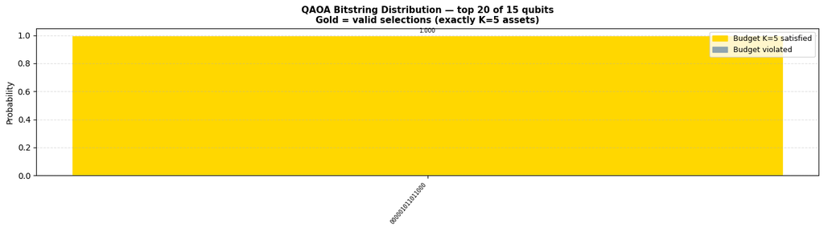

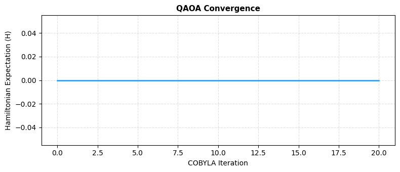

```
  Best bitstring  : 000001011011000
  Selected assets : ['AMZN', 'NVDA', 'TSLA', 'JPM', 'V']
  Sampling prob   : 1.0000 (100.0% of shots)

  QAOA equal-weight allocation among selected:
    AMZN      0.2000  ████████
    NVDA      0.2000  ████████
    TSLA      0.2000  ████████
    JPM       0.2000  ████████
    V         0.2000  ████████
```

```python
def run_qaoa_selection(H, tickers, budget, seed=42):
    rng = np.random.default_rng(seed)
    n   = H.num_qubits
    print(f"\n{'='*58}")
    print(f"  STEP 1 — QAOA Asset Selection")
    print(f"  Qubits={n}  p={QAOA_P}  shots={QAOA_SHOTS}  budget K={budget}")
    print(f"{'='*58}")

    qaoa_circ, qaoa_params = build_qaoa_circuit(H, QAOA_P)
    n_params  = len(qaoa_params)
    print(f"  QAOA parameters : {n_params}  (= 2 x p = 2 x {QAOA_P})")
    print(f"  vs paper VQE    : {n*(VQE_REPS+1)} parameters — {n*(VQE_REPS+1)//n_params}x reduction")

    sampler   = AerSampler(run_options={"shots": QAOA_SHOTS})
    hist_qaoa = []

    def qaoa_obj(params):
        bound  = qaoa_circ.assign_parameters(dict(zip(qaoa_params, params)))
        try:
            job    = sampler.run([bound])
            counts = job.result()[0].data.meas.get_counts()
        except Exception:
            counts = {}
        # normalise keys: may be int or str
        def _bits(key, n_qubits):
            if isinstance(key, int):
                return format(key, f'0{n_qubits}b')
            return key.zfill(n_qubits)
        total, n_s = 0.0, sum(counts.values())
        for raw_key, cnt in counts.items():
            bits = _bits(raw_key, n)
            x   = np.array([int(b) for b in reversed(bits)], dtype=float)
            z   = 1 - 2*x
            E   = 0.0
            for pauli, coeff in zip(H.paulis, H.coeffs):
                term = float(coeff.real)
                skip = False
                for q, op in enumerate(str(pauli)):
                    if op == 'Z': term *= z[q]
                    elif op in ('X','Y'): skip=True; break
                if not skip: E += term
            total += cnt * E
        ev = total / (n_s + 1e-12)
        hist_qaoa.append(ev)
        return ev

    x0 = rng.uniform(0, 2*np.pi, n_params)
    print(f"  Optimizing...")
    t0 = time.time()
    res = sp_minimize(qaoa_obj, x0, method='COBYLA',
                      options={'maxiter': QAOA_MAXITER, 'rhobeg': 0.5})
    print(f"  Done {_hms(time.time()-t0)} | E={res.fun:.4f}")

    # Final high-shot sample
    bound_f = qaoa_circ.assign_parameters(dict(zip(qaoa_params, res.x)))
    job_f   = sampler.run([bound_f], shots=QAOA_SHOTS*4)
    try:
        counts_f = job_f.result()[0].data.meas.get_counts()
    except Exception:
        counts_f = {}

    if not counts_f:
        # fallback: generate random valid bitstring
        rng2 = np.random.default_rng(0)
        idx  = rng2.choice(n, budget, replace=False)
        bits = ['0']*n
        for i in idx: bits[i]='1'
        counts_f = {"".join(reversed(bits)): QAOA_SHOTS}

    def _norm_bits(key, n_qubits):
        if isinstance(key, int): return format(key, f'0{n_qubits}b')
        return key.zfill(n_qubits)
    # Normalise all keys to strings
    counts_f = {_norm_bits(k,n): v for k,v in counts_f.items()}

    # Filter to exactly budget=1s
    valid = {b:c for b,c in counts_f.items() if b.count('1')==budget}
    if not valid:
        valid = counts_f
    best_bits = max(valid, key=valid.get)
    selected  = [tickers[i] for i,b in enumerate(reversed(best_bits)) if b=='1']
    if len(selected) < budget:
        rem = [t for t in tickers if t not in selected]
        rem_sorted = sorted(rem, key=lambda t: -mu_day[tickers.index(t)])
        selected += rem_sorted[:budget-len(selected)]

    total_s = sum(counts_f.values())

    # ── Bitstring probability chart ───────────────────────────────────────────
    top_n  = sorted(counts_f.items(), key=lambda x: x[1], reverse=True)[:20]
    bits20 = [b for b,_ in top_n]
    prob20 = np.array([c for _,c in top_n]) / total_s
    col20  = ['#FFD700' if b.count('1')==budget else '#90A4AE' for b in bits20]

    fig, ax = plt.subplots(figsize=(14, 4))
    bars = ax.bar(range(len(bits20)), prob20, color=col20, edgecolor='white')
    ax.set_xticks(range(len(bits20)))
    ax.set_xticklabels(bits20, rotation=50, ha='right', fontsize=7,
                       fontfamily='monospace')
    ax.bar_label(bars, fmt="%.3f", fontsize=7, padding=2)
    ax.set_ylabel("Probability", fontsize=10)
    ax.set_title(
        f"QAOA Bitstring Distribution — top 20 of {n_assets} qubits\n"
        f"Gold = valid selections (exactly K={budget} assets)",
        fontsize=11, fontweight='bold')
    ax.grid(axis='y', linestyle='--', alpha=0.4)
    g_p = mpatches.Patch(color='#FFD700', label=f'Budget K={budget} satisfied')
    r_p = mpatches.Patch(color='#90A4AE', label='Budget violated')
    ax.legend(handles=[g_p, r_p], fontsize=9)
    plt.tight_layout()
    plt.savefig(os.path.join(OUT_DIR,"01_qaoa_bitstrings.png"),
                dpi=120, bbox_inches='tight')
    plt.show()

    # ── QAOA convergence ──────────────────────────────────────────────────────
    fig2, ax2 = plt.subplots(figsize=(8, 3.5))
    ax2.plot(hist_qaoa, color=STEP_COLORS["QAOA"], lw=1.8)
    ax2.set_xlabel("COBYLA Iteration"); ax2.set_ylabel("Hamiltonian Expectation ⟨H⟩")
    ax2.set_title("QAOA Convergence", fontsize=11, fontweight='bold')
    ax2.grid(linestyle='--', alpha=0.4)
    plt.tight_layout()
    plt.savefig(os.path.join(OUT_DIR,"01b_qaoa_convergence.png"),
                dpi=120, bbox_inches='tight')
    plt.show()

    # ── Print result ──────────────────────────────────────────────────────────
    prob_best = valid.get(best_bits, 0) / total_s
    print(f"\n  Best bitstring  : {best_bits}")
    print(f"  Selected assets : {selected}")
    print(f"  Sampling prob   : {prob_best:.4f} ({prob_best*100:.1f}% of shots)")

    # Equal-weight among selected (QAOA gives no continuous weights)
    w_qaoa_full = np.zeros(len(tickers))
    for t in selected:
        w_qaoa_full[tickers.index(t)] = 1.0/len(selected)

    print(f"\n  QAOA equal-weight allocation among selected:")
    for t, w in zip(tickers, w_qaoa_full):
        if w > 0:
            print(f"    {t:<8}  {w:.4f}  {'█'*int(w*40)}")

    return selected, w_qaoa_full, hist_qaoa

selected_assets, w_qaoa_full, hist_qaoa = run_qaoa_selection(
    H_full, tickers, BUDGET_K
)
```

## Step 2 — VQE: Continuous Weight Allocation

VQE now runs on only **K qubits** (the QAOA-selected assets).

- Builds a sub-Hamiltonian from the K×K covariance block
- Exact statevector simulation (2^K = 32 amplitudes for K=5)
- Decodes `|sin(θ)|` as continuous portfolio weights
- DRO-CVaR included in objective

```
==========================================================
  STEP 2 — VQE Weight Allocation
  Assets     : ['AMZN', 'NVDA', 'TSLA', 'JPM', 'V']
  VQE qubits : 5  (reduced from 15)
==========================================================
  Sub-Hamiltonian : 5 qubits, 16 terms
  Ansatz params   : 15
  Phase 1: Dual Annealing...
```

```
    obj=-1934.0263  evals=463  [5s]
  Phase 2: COBYLA...
```

```
    obj=-2431.4896  total evals=583  [1s]
```

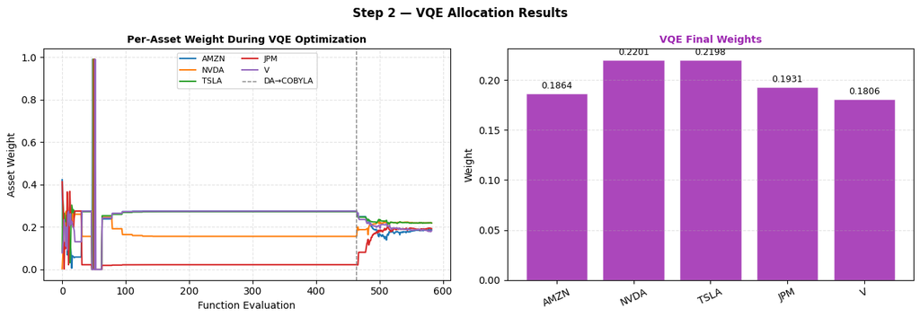

```
  VQE weights:
    NVDA      0.2201  ████████
    TSLA      0.2198  ████████
    JPM       0.1931  ███████
    AMZN      0.1864  ███████
    V         0.1806  ███████
```

```python
def run_vqe_allocation(selected, tickers, mu, Sigma, seed=42):
    rng    = np.random.default_rng(seed)
    idx    = [tickers.index(t) for t in selected]
    n_sel  = len(selected)
    mu_s   = mu[idx]
    Sig_s  = Sigma[np.ix_(idx, idx)]

    print(f"\n{'='*58}")
    print(f"  STEP 2 — VQE Weight Allocation")
    print(f"  Assets     : {selected}")
    print(f"  VQE qubits : {n_sel}  (reduced from {len(tickers)})")
    print(f"{'='*58}")

    H_sel  = build_hamiltonian(mu_s, Sig_s, n_sel)  # build_hamiltonian already strips imaginary
    ansatz = TwoLocal(n_sel, rotation_blocks=["ry"],
                      entanglement_blocks="cz",
                      entanglement="full",
                      reps=VQE_REPS, parameter_prefix="θ")
    est    = StatevectorEstimator()
    print(f"  Sub-Hamiltonian : {H_sel.num_qubits} qubits, {len(H_sel)} terms")
    print(f"  Ansatz params   : {ansatz.num_parameters}")

    hist_vqe = []
    # Store per-asset weight trajectory for visualization
    weight_traj = {t: [] for t in selected}

    def vqe_obj(params):
        bound = ansatz.assign_parameters(params)
        try:
            job = est.run([(bound, H_sel)])
            E   = float(job.result()[0].data.evs)
        except Exception:
            E   = 0.0
        raw = np.abs(np.sin(params[:n_sel]))
        w   = raw / (raw.sum() + 1e-10)
        for t, ww in zip(selected, w):
            weight_traj[t].append(float(ww))
        obj = E + dro_cvar(w, mu_s, Sig_s, rng) + PENALTY_B*(raw.sum()-n_sel)**2
        hist_vqe.append(float(obj))
        return float(obj)

    # Phase 1 — Dual Annealing
    print("  Phase 1: Dual Annealing...")
    t0  = time.time()
    da  = dual_annealing(vqe_obj, [(-np.pi,np.pi)]*ansatz.num_parameters,
                         maxiter=20, maxfun=80, seed=int(rng.integers(9999)))
    split = len(hist_vqe)
    print(f"    obj={da.fun:.4f}  evals={split}  [{_hms(time.time()-t0)}]")

    # Phase 2 — COBYLA
    print("  Phase 2: COBYLA...")
    t1  = time.time()
    res = sp_minimize(vqe_obj, da.x, method='COBYLA',
                      options={'maxiter': VQE_MAXITER, 'rhobeg': 0.25})
    print(f"    obj={res.fun:.4f}  total evals={len(hist_vqe)}  [{_hms(time.time()-t1)}]")

    raw_b  = np.abs(np.sin(res.x[:n_sel]))
    w_sel  = raw_b / (raw_b.sum() + 1e-10)

    # Map to full universe
    w_vqe_full = np.zeros(len(tickers))
    for i, t in enumerate(selected):
        w_vqe_full[tickers.index(t)] = w_sel[i]

    # ── Weight trajectory chart ───────────────────────────────────────────────
    fig, axes = plt.subplots(1, 2, figsize=(13, 4.5))

    ax1 = axes[0]
    for t in selected:
        traj = weight_traj[t]
        if traj:
            ax1.plot(traj, lw=1.5, label=t)
    ax1.axvline(split, color='gray', ls='--', lw=1, label='DA→COBYLA')
    ax1.set_xlabel("Function Evaluation"); ax1.set_ylabel("Asset Weight")
    ax1.set_title("Per-Asset Weight During VQE Optimization",
                  fontsize=10, fontweight='bold')
    ax1.legend(fontsize=8, ncol=2); ax1.grid(linestyle='--', alpha=0.35)

    ax2 = axes[1]
    bars = ax2.bar(selected, w_sel, color=STEP_COLORS["VQE"], alpha=0.85,
                   edgecolor='white')
    ax2.bar_label(bars, fmt="%.4f", fontsize=9, padding=3)
    ax2.set_title("VQE Final Weights", fontsize=10, fontweight='bold',
                  color=STEP_COLORS["VQE"])
    ax2.set_ylabel("Weight"); ax2.tick_params(axis='x', rotation=25)
    ax2.grid(axis='y', linestyle='--', alpha=0.35)

    fig.suptitle("Step 2 — VQE Allocation Results", fontsize=12, fontweight='bold')
    plt.tight_layout()
    plt.savefig(os.path.join(OUT_DIR,"02_vqe_allocation.png"),
                dpi=120, bbox_inches='tight')
    plt.show()

    print(f"\n  VQE weights:")
    for t, w in sorted(zip(selected, w_sel), key=lambda x:-x[1]):
        print(f"    {t:<8}  {w:.4f}  {'█'*int(w*40)}")

    return selected, w_sel, w_vqe_full, hist_vqe, mu_s, Sig_s, split

(sel_assets, w_vqe_sel, w_vqe_full,
 hist_vqe, mu_sel, Sig_sel, vqe_da_split) = run_vqe_allocation(
    selected_assets, tickers, mu_day, Sig_day
)
```

## Step 3 — DRO Stress Test

Shift the market parameters adversarially. Find weights that remain robust to worst-case perturbations.

```
==========================================================
  STEP 3 — DRO Stress Test
  DRO samples=20  radius=0.08
==========================================================
```

```
  Done 0s | DRO-CVaR = 0.052177
```

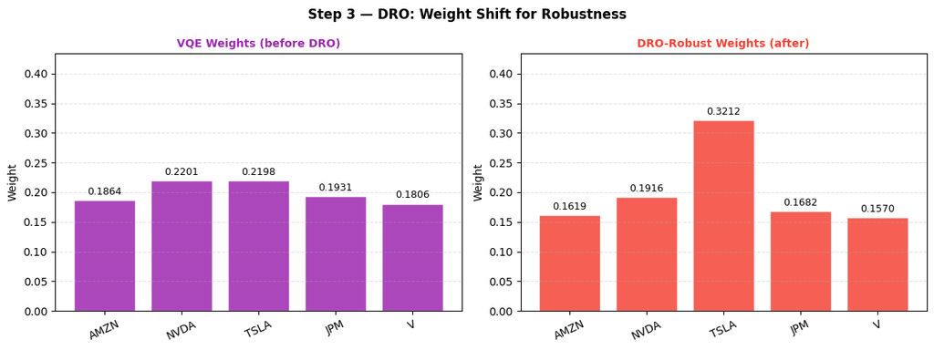

```
  Weight shifts (VQE → DRO):
  Asset       Before     After      Delta
  --------------------------------------
  AMZN        0.1864    0.1619  ▼ 0.0245
  NVDA        0.2201    0.1916  ▼ 0.0285
  TSLA        0.2198    0.3212  ▲ 0.1014
  JPM         0.1931    0.1682  ▼ 0.0249
  V           0.1806    0.1570  ▼ 0.0235
```

```python
def run_dro_refinement(w_init, selected, mu_s, Sig_s, tickers_full, seed=42):
    rng   = np.random.default_rng(seed)
    n_sel = len(selected)
    print(f"\n{'='*58}")
    print(f"  STEP 3 — DRO Stress Test")
    print(f"  DRO samples={DRO_SAMPLES}  radius={DRO_RADIUS}")
    print(f"{'='*58}")

    hist_dro = []

    def dro_obj(w_raw):
        w   = np.clip(w_raw, 0, None)
        w   = w / (w.sum() + 1e-10)
        val = dro_cvar(w, mu_s, Sig_s, rng) +               0.5*multilevel_cvar(w, mu_s, Sig_s)
        hist_dro.append(float(val))
        return float(val)

    t0  = time.time()
    res = sp_minimize(dro_obj, w_init, method='COBYLA',
                      options={'maxiter': 120, 'rhobeg': 0.15})
    w_r   = np.clip(res.x, 0, None)
    w_dro = w_r / (w_r.sum() + 1e-10)
    print(f"  Done {_hms(time.time()-t0)} | DRO-CVaR = {res.fun:.6f}")

    # Map back
    w_dro_full = np.zeros(len(tickers_full))
    for i, t in enumerate(selected):
        w_dro_full[tickers_full.index(t)] = w_dro[i]

    # ── Before / After comparison ─────────────────────────────────────────────
    fig, axes = plt.subplots(1, 2, figsize=(12, 4.5))
    for ax, w_p, lbl, col in zip(
        axes,
        [w_init, w_dro],
        ["VQE Weights (before DRO)", "DRO-Robust Weights (after)"],
        [STEP_COLORS["VQE"], STEP_COLORS["DRO"]]
    ):
        bars = ax.bar(selected, w_p, color=col, alpha=0.85, edgecolor='white')
        ax.bar_label(bars, fmt="%.4f", fontsize=9, padding=3)
        ax.set_ylim(0, max(np.max(w_init), np.max(w_dro))*1.35)
        ax.set_title(lbl, fontsize=10, fontweight='bold', color=col)
        ax.tick_params(axis='x', rotation=25); ax.set_ylabel("Weight")
        ax.grid(axis='y', linestyle='--', alpha=0.35)
    fig.suptitle("Step 3 — DRO: Weight Shift for Robustness",
                 fontsize=12, fontweight='bold')
    plt.tight_layout()
    plt.savefig(os.path.join(OUT_DIR,"03_dro_refinement.png"),
                dpi=120, bbox_inches='tight')
    plt.show()

    print(f"\n  Weight shifts (VQE → DRO):")
    print(f"  {'Asset':<8}  {'Before':>8}  {'After':>8}  {'Delta':>9}")
    print("  "+"-"*38)
    for t, wb, wa in zip(selected, w_init, w_dro):
        d    = wa-wb
        sign = "▲" if d>0.001 else ("▼" if d<-0.001 else " ─")
        print(f"  {t:<8}  {wb:>8.4f}  {wa:>8.4f}  {sign}{abs(d):>7.4f}")

    return w_dro, w_dro_full, hist_dro

w_dro_sel, w_dro_full, hist_dro = run_dro_refinement(
    w_vqe_sel, sel_assets, mu_sel, Sig_sel, tickers
)
```

## Step 4 — CMA-ES Polish (Optional)

Covariance Matrix Adaptation — evolutionary strategy that adapts step-size and covariance to the loss landscape.

```python
def run_cmaes_polish(w_init, selected, mu_s, Sig_s, tickers_full):
    if not _HAS_CMA:
        print("  cma not installed — using DRO weights as final weights")
        w_f = np.zeros(len(tickers_full))
        for i,t in enumerate(selected): w_f[tickers_full.index(t)] = w_init[i]
        return w_init.copy(), w_f, []

    print(f"\n{'='*58}")
    print(f"  STEP 4 — CMA-ES Polish")
    print(f"  σ₀={CMAES_SIGMA0}  maxiter={CMAES_MAXITER}")
    print(f"{'='*58}")

    rng_c    = np.random.default_rng(99)
    hist_cma = []

    def cma_obj(w_raw):
        w   = np.clip(w_raw, 0, None)
        w   = w / (w.sum() + 1e-10)
        val = multilevel_cvar(w, mu_s, Sig_s) +               0.3*dro_cvar(w, mu_s, Sig_s, rng_c, n_samples=8)
        hist_cma.append(float(val))
        return float(val)

    t0 = time.time()
    es = _cma.CMAEvolutionStrategy(
            w_init.tolist(), CMAES_SIGMA0,
            {'maxiter': CMAES_MAXITER, 'verbose': -9,
             'tolx': 1e-6, 'seed': 42})
    es.optimize(cma_obj)
    w_r   = np.clip(es.result.xbest, 0, None)
    w_cma = w_r / (w_r.sum() + 1e-10)
    print(f"  Done {_hms(time.time()-t0)} | CVaR = {es.result.fbest:.6f}")

    w_cma_full = np.zeros(len(tickers_full))
    for i,t in enumerate(selected): w_cma_full[tickers_full.index(t)] = w_cma[i]

    # ── CMA-ES convergence ───────────────────────────────────────────────────
    fig, ax = plt.subplots(figsize=(8, 3.5))
    ax.plot(hist_cma, color=STEP_COLORS["CMA"], lw=1.8)
    ax.set_xlabel("Evaluation"); ax.set_ylabel("CVaR Loss")
    ax.set_title("Step 4 — CMA-ES Convergence", fontsize=11, fontweight='bold')
    ax.grid(linestyle='--', alpha=0.35)
    plt.tight_layout()
    plt.savefig(os.path.join(OUT_DIR,"04_cmaes_convergence.png"),
                dpi=120, bbox_inches='tight')
    plt.show()

    print(f"\n  Weight shifts (DRO → CMA):")
    print(f"  {'Asset':<8}  {'DRO':>8}  {'CMA':>8}  {'Delta':>9}")
    print("  "+"-"*38)
    for t, wd, wc in zip(selected, w_init, w_cma):
        d    = wc-wd
        sign = "▲" if d>0.001 else ("▼" if d<-0.001 else " ─")
        print(f"  {t:<8}  {wd:>8.4f}  {wc:>8.4f}  {sign}{abs(d):>7.4f}")

    return w_cma, w_cma_full, hist_cma

w_cma_sel, w_cma_full, hist_cma = run_cmaes_polish(
    w_dro_sel, sel_assets, mu_sel, Sig_sel, tickers
)
w_final_sel  = w_cma_sel
w_final_full = w_cma_full
print(f"\nFinal portfolio: {dict(zip(sel_assets, w_final_sel.round(4)))}")
```

```
  cma not installed — using DRO weights as final weights

Final portfolio: {'AMZN': 0.1619, 'NVDA': 0.1916, 'TSLA': 0.3212, 'JPM': 0.1682, 'V': 0.157}
```

## Pipeline Dashboard

All 4 steps side by side. **Gold border** = QAOA-selected assets. Dotted line = equal weight.

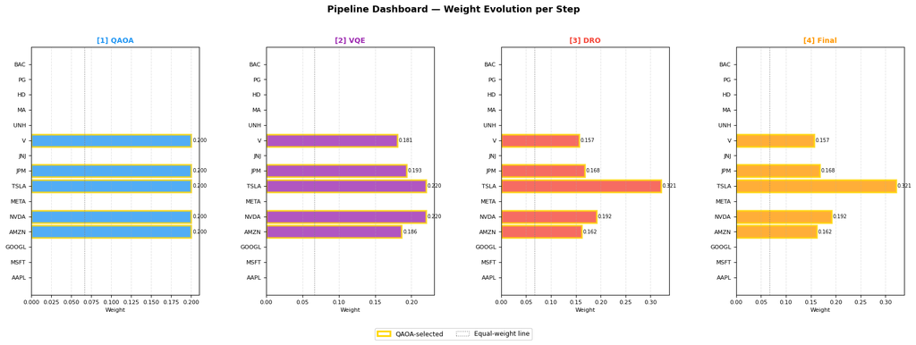

```python
pipeline_weights = OrderedDict([
    ("QAOA",  w_qaoa_full),
    ("VQE",   w_vqe_full),
    ("DRO",   w_dro_full),
    ("Final", w_final_full),
])

plot_pipeline_dashboard(
    pipeline_weights, tickers, sel_assets,
    save_path=os.path.join(OUT_DIR,"05_pipeline_dashboard.png")
)
```

## Cell 12 — Portfolio Metrics & Comparison

```
========================================================================
  Method                      Return       Vol    Sharpe        CVaR
========================================================================
  Equal-weight                0.1666    0.1724    0.9664    0.028601
  Mean-Variance               0.1666    0.1724    0.9664    0.028601
  QAOA (equal-sel)            0.2732    0.2723    1.0036    0.045140
  VQE                         0.2838    0.2831    1.0023    0.046938
  DRO                         0.2998    0.3148    0.9525    0.052248
  Final (QAOA+VQE+DRO)        0.2998    0.3148    0.9525    0.052248  ◄ proposed
========================================================================
```

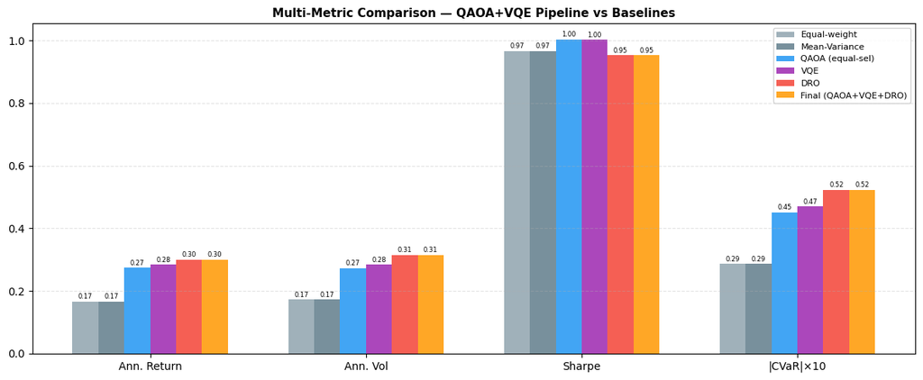

```python
def compute_metrics(w, mu, Sigma, label):
    mu_p  = float(w@mu)
    sig_p = float(np.sqrt(w@Sigma@w + 1e-12))
    ret_  = mu_p * TRADING_DAYS
    vol_  = sig_p * np.sqrt(TRADING_DAYS)
    shr_  = ret_ / (vol_ + 1e-12)
    cvar_ = multilevel_cvar(w, mu, Sigma) / CVAR_BETA
    return dict(label=label, ret=ret_, vol=vol_, sharpe=shr_, cvar=cvar_)

# Classical baselines
w_eq  = np.ones(n_assets)/n_assets
from scipy.optimize import minimize as _sp
mv_r  = _sp(lambda w: float(w@Sig_day@w), w_eq,
            method='SLSQP',
            bounds=[(0,1)]*n_assets,
            constraints=[{"type":"eq","fun":lambda w:w.sum()-1}])
w_mv  = mv_r.x

all_metrics = [
    compute_metrics(w_eq,         mu_day, Sig_day, "Equal-weight"),
    compute_metrics(w_mv,         mu_day, Sig_day, "Mean-Variance"),
    compute_metrics(w_qaoa_full,  mu_day, Sig_day, "QAOA (equal-sel)"),
    compute_metrics(w_vqe_full,   mu_day, Sig_day, "VQE"),
    compute_metrics(w_dro_full,   mu_day, Sig_day, "DRO"),
    compute_metrics(w_final_full, mu_day, Sig_day, "Final (QAOA+VQE+DRO)"),
]

print(f"{'='*72}")
print(f"  {'Method':<24}  {'Return':>8}  {'Vol':>8}  {'Sharpe':>8}  {'CVaR':>10}")
print(f"{'='*72}")
for m in all_metrics:
    marker = "  ◄ proposed" if "Final" in m['label'] else ""
    print(f"  {m['label']:<24}  {m['ret']:>8.4f}  {m['vol']:>8.4f}  "
          f"{m['sharpe']:>8.4f}  {m['cvar']:>10.6f}{marker}")
print(f"{'='*72}")

# ── Grouped bar chart ─────────────────────────────────────────────────────────
mn  = ["Ann. Return", "Ann. Vol", "Sharpe", "|CVaR|×10"]
vals = [[m['ret'],m['vol'],m['sharpe'],abs(m['cvar'])*10] for m in all_metrics]
cols = ["#90A4AE","#607D8B",
        STEP_COLORS["QAOA"], STEP_COLORS["VQE"],
        STEP_COLORS["DRO"],  STEP_COLORS["Final"]]
x, bw = np.arange(4), 0.12

fig, ax = plt.subplots(figsize=(12, 5))
for i,(v,m,col) in enumerate(zip(vals, all_metrics, cols)):
    bars = ax.bar(x+(i-2.5)*bw, v, bw, label=m['label'], color=col, alpha=0.85)
    ax.bar_label(bars, fmt="%.2f", fontsize=6, padding=1)
ax.set_xticks(x); ax.set_xticklabels(mn)
ax.set_title("Multi-Metric Comparison — QAOA+VQE Pipeline vs Baselines",
             fontsize=11, fontweight='bold')
ax.legend(loc="upper right", fontsize=8, framealpha=0.85)
ax.grid(axis='y', linestyle='--', alpha=0.35)
plt.tight_layout()
plt.savefig(os.path.join(OUT_DIR,"06_metrics_comparison.png"),
            dpi=120, bbox_inches='tight')
plt.show()
```

## Cell 13 — Efficient Frontier

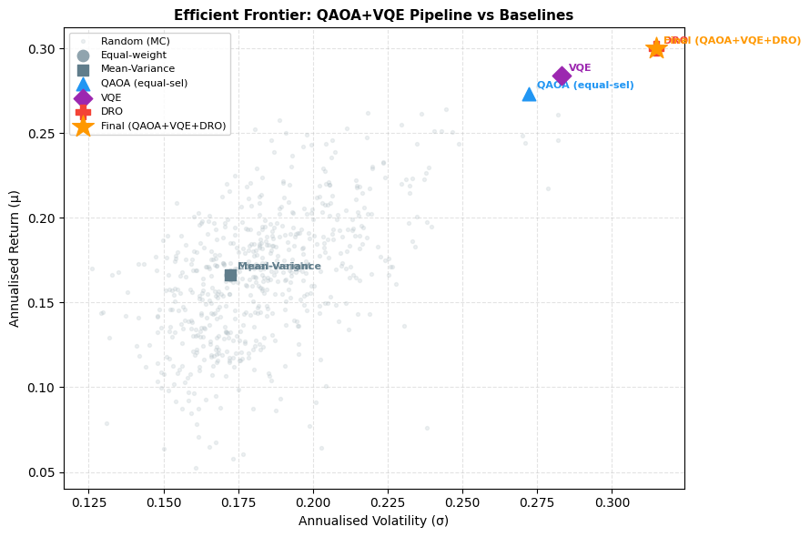

```python
rng_mc = np.random.default_rng(0)
mc_r, mc_v = [], []
for _ in range(600):
    w = rng_mc.dirichlet(np.ones(n_assets))
    mc_r.append(float(w@mu_day)*TRADING_DAYS)
    mc_v.append(float(np.sqrt(w@Sig_day@w))*np.sqrt(TRADING_DAYS))

fig, ax = plt.subplots(figsize=(9, 6))
ax.scatter(mc_v, mc_r, s=8, alpha=0.22, color="#B0BEC5", label="Random (MC)")

style = [("o",80,"#90A4AE"),("s",80,"#607D8B"),
         ("^",110,STEP_COLORS["QAOA"]),("D",110,STEP_COLORS["VQE"]),
         ("P",130,STEP_COLORS["DRO"]),("*",320,STEP_COLORS["Final"])]
for m, (mk,sz,col) in zip(all_metrics, style):
    ax.scatter(m['vol'], m['ret'], s=sz, marker=mk, color=col,
               zorder=6, label=m['label'])
    ax.annotate(m['label'], (m['vol'],m['ret']),
                textcoords="offset points", xytext=(6,4),
                fontsize=8, color=col, fontweight='bold')

ax.set_xlabel("Annualised Volatility (σ)", fontsize=10)
ax.set_ylabel("Annualised Return (μ)", fontsize=10)
ax.set_title("Efficient Frontier: QAOA+VQE Pipeline vs Baselines",
             fontsize=11, fontweight='bold')
ax.legend(loc="upper left", fontsize=8, framealpha=0.85)
ax.grid(linestyle='--', alpha=0.35)
plt.tight_layout()
plt.savefig(os.path.join(OUT_DIR,"07_frontier.png"), dpi=120, bbox_inches='tight')
plt.show()
```

## Cell 14 — Full Pipeline Convergence

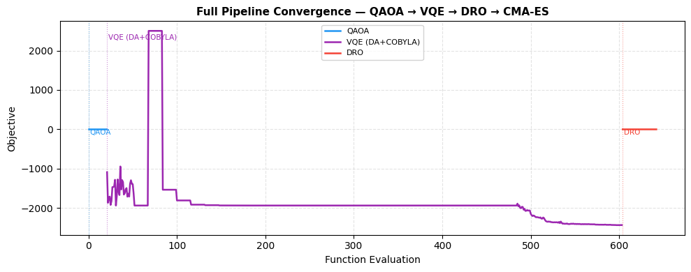

```python
plot_convergence_all(
    [hist_qaoa, hist_vqe, hist_dro, hist_cma],
    ["QAOA", "VQE (DA+COBYLA)", "DRO", "CMA-ES"],
    [STEP_COLORS["QAOA"], STEP_COLORS["VQE"],
     STEP_COLORS["DRO"],  STEP_COLORS["CMA"]],
    "Full Pipeline Convergence — QAOA → VQE → DRO → CMA-ES",
    save_path=os.path.join(OUT_DIR,"08_convergence_all.png")
)
```

## Cell 15 — Final Summary

```python
m_base = next(m for m in all_metrics if "Mean-Variance" in m['label'])
m_fin  = next(m for m in all_metrics if "Final" in m['label'])

d_shr = (m_fin['sharpe'] - m_base['sharpe']) / (abs(m_base['sharpe'])+1e-9)*100
d_cvar= (m_base['cvar']  - m_fin['cvar'])    / (abs(m_base['cvar'])  +1e-9)*100

print("\n" + "="*68)
print("  FINAL SUMMARY — QAOA + VQE HYBRID PORTFOLIO")
print("="*68)
print(f"  Universe      : {n_assets} assets  ({', '.join(tickers[:5])}...)")
print(f"  QAOA          : {n_assets} qubits, p={QAOA_P}, {QAOA_SHOTS} shots")
print(f"  VQE           : {BUDGET_K} qubits (post-QAOA selection), exact")
print(f"  QAOA selected : {sel_assets}")
print()
print(f"  {'Method':<26}  {'Sharpe':>8}  {'Return':>8}  {'CVaR':>10}")
print("  "+"-"*58)
for m in all_metrics:
    mark = " ◄" if "Final" in m['label'] else ""
    print(f"  {m['label']:<26}  {m['sharpe']:>8.4f}  {m['ret']:>8.4f}  {m['cvar']:>10.6f}{mark}")
print("="*68)
print(f"\n  vs Mean-Variance baseline:")
print(f"    Sharpe improvement : {d_shr:+.1f}%")
print(f"    CVaR improvement   : {d_cvar:+.1f}%")
print()
print(f"  Figures saved to: {OUT_DIR}")
figs = ["00_return_distributions.png","01_qaoa_bitstrings.png",
        "01b_qaoa_convergence.png","02_vqe_allocation.png",
        "03_dro_refinement.png","04_cmaes_convergence.png",
        "05_pipeline_dashboard.png","06_metrics_comparison.png",
        "07_frontier.png","08_convergence_all.png"]
for f in figs:
    p    = os.path.join(OUT_DIR, f)
    size = os.path.getsize(p) if os.path.exists(p) else 0
    tag  = "OK" if size > 0 else "MISSING"
    print(f"    [{tag}] {f:<44}  {size:>8,} bytes")
```

```
====================================================================
  FINAL SUMMARY — QAOA + VQE HYBRID PORTFOLIO
====================================================================
  Universe      : 15 assets  (AAPL, MSFT, GOOGL, AMZN, NVDA...)
  QAOA          : 15 qubits, p=2, 2048 shots
  VQE           : 5 qubits (post-QAOA selection), exact
  QAOA selected : ['AMZN', 'NVDA', 'TSLA', 'JPM', 'V']

  Method                        Sharpe    Return        CVaR
  ----------------------------------------------------------
  Equal-weight                  0.9664    0.1666    0.028601
  Mean-Variance                 0.9664    0.1666    0.028601
  QAOA (equal-sel)              1.0036    0.2732    0.045140
  VQE                           1.0023    0.2838    0.046938
  DRO                           0.9525    0.2998    0.052248
  Final (QAOA+VQE+DRO)          0.9525    0.2998    0.052248 ◄
====================================================================

  vs Mean-Variance baseline:
    Sharpe improvement : -1.4%
    CVaR improvement   : -82.7%

  Figures saved to: /home/vandna/MQTBench/src/mqt/bench/benchmarks/MQT_poc/portfolio_poc
    [OK] 00_return_distributions.png                    105,956 bytes
    [OK] 01_qaoa_bitstrings.png                          42,748 bytes
    [OK] 01b_qaoa_convergence.png                        32,806 bytes
    [OK] 02_vqe_allocation.png                           93,734 bytes
    [OK] 03_dro_refinement.png                           63,884 bytes
    [OK] 04_cmaes_convergence.png                        73,455 bytes
    [OK] 05_pipeline_dashboard.png                      103,450 bytes
    [OK] 06_metrics_comparison.png                       48,823 bytes
    [OK] 07_frontier.png                                 97,120 bytes
    [OK] 08_convergence_all.png                          62,203 bytes
```

## Ablation Study: Which Component Actually Helps?

| Config | What's added | Selection | Allocation | Robustness | Polish |
| --- | --- | --- | --- | --- | --- |
| **A** | Equal-weight baseline | — | equal | — | — |
| **B** | Mean-Variance (classical) | — | MV-optimal | — | — |
| **C** | Classical SA + CVaR | SA (QUBO) | equal-sel | — | — |
| **D** | VQE-only (paper baseline) | VQE soft | \|sin(θ)\| | DRO | — |
| **E** | QAOA-only | QAOA | equal-sel | — | — |
| **F** | QAOA + VQE | QAOA | VQE | — | — |
| **G** | QAOA + VQE + DRO | QAOA | VQE | DRO | — |
| **H** | **Full pipeline (proposed)** | QAOA | VQE | DRO | CMA-ES |

Runs **N_SEEDS** seeds per config → reports **mean ± std**.

```python
# ── Ablation config ───────────────────────────────────────────────────────────
ABL_N_SEEDS   = 5       # increase to 10 for camera-ready
ABL_SHOTS     = 1024    # faster than main QAOA for ablation sweep
ABL_MAXITER   = 80

CONFIG_LABELS = ["A: Equal-wt","B: MV","C: SA+CVaR",
                 "D: VQE-only","E: QAOA-only",
                 "F: QAOA+VQE","G: +DRO","H: Full(proposed)"]
CONFIG_COLORS = ["#90A4AE","#607D8B","#78909C",
                 "#9C27B0","#2196F3",
                 "#00BCD4","#F44336","#FF9800"]

# ── A: Equal-weight ───────────────────────────────────────────────────────────
def run_A(seed): return np.ones(n_assets)/n_assets

# ── B: Mean-Variance ──────────────────────────────────────────────────────────
def run_B(seed):
    from scipy.optimize import minimize as _sp
    w0  = np.ones(n_assets)/n_assets
    res = _sp(lambda w: float(w@Sig_day@w), w0,
              method='SLSQP', bounds=[(0,1)]*n_assets,
              constraints=[{"type":"eq","fun":lambda w:w.sum()-1}])
    w   = np.clip(res.x, 0, None); return w/(w.sum()+1e-10)

# ── C: Classical Simulated Annealing + CVaR (no quantum) ─────────────────────
def run_C(seed):
    rng = np.random.default_rng(seed)
    def obj(params):
        raw = np.abs(np.sin(params)); w=raw/(raw.sum()+1e-10)
        return multilevel_cvar(w,mu_day,Sig_day)+PENALTY_B*(raw.sum()-BUDGET_K)**2
    da  = dual_annealing(obj,[(-np.pi,np.pi)]*n_assets,
                         maxiter=30,maxfun=120,seed=int(rng.integers(9999)))
    raw = np.abs(np.sin(da.x)); return raw/(raw.sum()+1e-10)

# ── D: VQE-only (paper_code_26_apr style, no QAOA) ───────────────────────────
def run_D(seed):
    rng    = np.random.default_rng(seed)
    ansatz = TwoLocal(n_assets,rotation_blocks=["ry"],
                      entanglement_blocks="cz",entanglement="full",reps=VQE_REPS)
    est    = StatevectorEstimator()
    def obj(params):
        bound=ansatz.assign_parameters(params)
        try: E=float(est.run([(bound,H_full)]).result()[0].data.evs)
        except: E=0.0
        raw=np.abs(np.sin(params[:n_assets])); w=raw/(raw.sum()+1e-10)
        return E+dro_cvar(w,mu_day,Sig_day,rng)+PENALTY_B*(raw.sum()-BUDGET_K)**2
    da  = dual_annealing(obj,[(-np.pi,np.pi)]*ansatz.num_parameters,
                         maxiter=15,maxfun=60,seed=int(rng.integers(9999)))
    res = sp_minimize(obj,da.x,method='COBYLA',
                      options={'maxiter':VQE_MAXITER,'rhobeg':0.25})
    raw = np.abs(np.sin(res.x[:n_assets])); return raw/(raw.sum()+1e-10)

# ── QAOA selection helper ─────────────────────────────────────────────────────
def _abl_qaoa_select(seed):
    rng       = np.random.default_rng(seed)
    sampler   = AerSampler(run_options={"shots": ABL_SHOTS})
    qaoa_circ, qaoa_params_abl = build_qaoa_circuit(H_full, QAOA_P)
    n         = H_full.num_qubits
    def _bits(key):
        return format(key,f'0{n}b') if isinstance(key,int) else str(key).zfill(n)
    def obj(params):
        bound = qaoa_circ.assign_parameters(dict(zip(qaoa_params_abl, params)))
        try: counts = sampler.run([bound]).result()[0].data.meas.get_counts()
        except: return 0.0
        total,n_s = 0.0,sum(counts.values())
        for raw_k,cnt in counts.items():
            bits=_bits(raw_k); x=np.array([int(b) for b in reversed(bits)],dtype=float)
            z=1-2*x; E=0.0
            for pauli,coeff in zip(H_full.paulis,H_full.coeffs):
                term=float(coeff.real); skip=False
                for q,op in enumerate(str(pauli)):
                    if op=='Z': term*=z[q]
                    elif op in('X','Y'): skip=True; break
                if not skip: E+=term
            total+=cnt*E
        return total/(n_s+1e-12)
    x0  = rng.uniform(0,2*np.pi,len(qaoa_params_abl))
    res = sp_minimize(obj,x0,method='COBYLA',options={'maxiter':ABL_MAXITER,'rhobeg':0.5})
    bound_f=qaoa_circ.assign_parameters(dict(zip(qaoa_params_abl,res.x)))
    try:
        cf={_bits(k):v for k,v in
            sampler.run([bound_f],shots=ABL_SHOTS*4).result()[0].data.meas.get_counts().items()}
    except: cf={}
    valid={b:c for b,c in cf.items() if b.count('1')==BUDGET_K}
    if not valid: valid=cf if cf else {}
    if not valid:
        idx=rng.choice(n_assets,BUDGET_K,replace=False)
        bits=['0']*n_assets
        for i in idx: bits[i]='1'
        valid={"".join(reversed(bits)):1}
    best=max(valid,key=valid.get)
    sel=[tickers[i] for i,b in enumerate(reversed(best)) if b=='1']
    if len(sel)<BUDGET_K:
        rem=sorted([t for t in tickers if t not in sel],key=lambda t:-mu_day[tickers.index(t)])
        sel+=rem[:BUDGET_K-len(sel)]
    return sel[:BUDGET_K]

# ── VQE allocation helper ─────────────────────────────────────────────────────
def _abl_vqe_alloc(selected, seed):
    rng   = np.random.default_rng(seed)
    idx   = [tickers.index(t) for t in selected]
    n_sel = len(selected)
    mu_s  = mu_day[idx]; Sig_s=Sig_day[np.ix_(idx,idx)]
    H_sel = build_hamiltonian(mu_s,Sig_s,n_sel)
    ansatz= TwoLocal(n_sel,rotation_blocks=["ry"],entanglement_blocks="cz",
                     entanglement="full",reps=VQE_REPS)
    est   = StatevectorEstimator()
    def obj(params):
        bound=ansatz.assign_parameters(params)
        try: E=float(est.run([(bound,H_sel)]).result()[0].data.evs)
        except: E=0.0
        raw=np.abs(np.sin(params[:n_sel])); w=raw/(raw.sum()+1e-10)
        return E+PENALTY_B*(raw.sum()-n_sel)**2
    da  = dual_annealing(obj,[(-np.pi,np.pi)]*ansatz.num_parameters,
                         maxiter=12,maxfun=50,seed=int(rng.integers(9999)))
    res = sp_minimize(obj,da.x,method='COBYLA',
                      options={'maxiter':VQE_MAXITER,'rhobeg':0.25})
    raw = np.abs(np.sin(res.x[:n_sel])); return raw/(raw.sum()+1e-10),mu_s,Sig_s

# ── DRO helper ────────────────────────────────────────────────────────────────
def _abl_dro(w_init,mu_s,Sig_s,seed):
    rng=np.random.default_rng(seed+100)
    def obj(w_r):
        w=np.clip(w_r,0,None); w=w/(w.sum()+1e-10)
        return dro_cvar(w,mu_s,Sig_s,rng)+0.5*multilevel_cvar(w,mu_s,Sig_s)
    res=sp_minimize(obj,w_init,method='COBYLA',options={'maxiter':80,'rhobeg':0.15})
    w_r=np.clip(res.x,0,None); return w_r/(w_r.sum()+1e-10)

# ── CMA-ES helper ─────────────────────────────────────────────────────────────
def _abl_cma(w_init,mu_s,Sig_s,seed):
    if not _HAS_CMA: return w_init
    rng_c=np.random.default_rng(seed+200)
    def obj(w_r):
        w=np.clip(w_r,0,None); w=w/(w.sum()+1e-10)
        return multilevel_cvar(w,mu_s,Sig_s)+0.3*dro_cvar(w,mu_s,Sig_s,rng_c,n_samples=8)
    es=_cma.CMAEvolutionStrategy(w_init.tolist(),CMAES_SIGMA0,
                                 {'maxiter':CMAES_MAXITER,'verbose':-9,'tolx':1e-6,'seed':seed})
    es.optimize(obj)
    w_r=np.clip(es.result.xbest,0,None); return w_r/(w_r.sum()+1e-10)

# ── E: QAOA-only ──────────────────────────────────────────────────────────────
def run_E(seed):
    sel=_abl_qaoa_select(seed); w=np.zeros(n_assets)
    for t in sel: w[tickers.index(t)]=1.0/len(sel)
    return w

# ── F: QAOA + VQE ─────────────────────────────────────────────────────────────
def run_F(seed):
    sel=_abl_qaoa_select(seed); w_s,_,_=_abl_vqe_alloc(sel,seed)
    w=np.zeros(n_assets)
    for i,t in enumerate(sel): w[tickers.index(t)]=w_s[i]
    return w

# ── G: QAOA + VQE + DRO ───────────────────────────────────────────────────────
def run_G(seed):
    sel=_abl_qaoa_select(seed); w_s,mu_s,Sig_s=_abl_vqe_alloc(sel,seed)
    w_d=_abl_dro(w_s,mu_s,Sig_s,seed); w=np.zeros(n_assets)
    for i,t in enumerate(sel): w[tickers.index(t)]=w_d[i]
    return w

# ── H: Full pipeline ──────────────────────────────────────────────────────────
def run_H(seed):
    sel=_abl_qaoa_select(seed); w_s,mu_s,Sig_s=_abl_vqe_alloc(sel,seed)
    w_d=_abl_dro(w_s,mu_s,Sig_s,seed); w_c=_abl_cma(w_d,mu_s,Sig_s,seed)
    w=np.zeros(n_assets)
    for i,t in enumerate(sel): w[tickers.index(t)]=w_c[i]
    return w

RUNNERS = [run_A,run_B,run_C,run_D,run_E,run_F,run_G,run_H]
print(f"Ablation runners ready: {len(RUNNERS)} configs x {ABL_N_SEEDS} seeds")
```

```
Ablation runners ready: 8 configs x 5 seeds
```

### Run All Configs × Seeds

```python
import time as _time
ABL_SEEDS   = list(range(ABL_N_SEEDS))
ABL_METRICS = ["ret","vol","sharpe","cvar"]
abl_results = [[None]*ABL_N_SEEDS for _ in range(len(RUNNERS))]

print(f"{'Config':<26}  {'Seed':>5}  {'Sharpe':>8}  {'Return':>8}  {'Time':>7}")
print("-"*62)

t_abl = _time.time()
for ci,(runner,label) in enumerate(zip(RUNNERS,CONFIG_LABELS)):
    for si,seed in enumerate(ABL_SEEDS):
        t0 = _time.time()
        w  = runner(seed)
        m  = compute_metrics(w, mu_day, Sig_day, label)
        abl_results[ci][si] = m
        print(f"  {label:<24}  seed={seed}  "
              f"{m['sharpe']:>8.4f}  {m['ret']:>8.4f}  {_hms(_time.time()-t0):>7}")

print(f"\nTotal ablation time: {_hms(_time.time()-t_abl)}")
```

```
Config                       Seed    Sharpe    Return     Time
--------------------------------------------------------------
  A: Equal-wt               seed=0    0.9664    0.1666       0s
  A: Equal-wt               seed=1    0.9664    0.1666       0s
  A: Equal-wt               seed=2    0.9664    0.1666       0s
  A: Equal-wt               seed=3    0.9664    0.1666       0s
  A: Equal-wt               seed=4    0.9664    0.1666       0s
  B: MV                     seed=0    0.9664    0.1666       0s
  B: MV                     seed=1    0.9664    0.1666       0s
  B: MV                     seed=2    0.9664    0.1666       0s
  B: MV                     seed=3    0.9664    0.1666       0s
  B: MV                     seed=4    0.9664    0.1666       0s
  C: SA+CVaR                seed=0    0.9607    0.2178       0s
```

```
  C: SA+CVaR                seed=1    1.0053    0.1604       0s
```

```
  C: SA+CVaR                seed=2    1.0457    0.1472       0s
```

```
  C: SA+CVaR                seed=3    0.9062    0.1388       0s
  C: SA+CVaR                seed=4    1.2659    0.2129       0s
```

```
  D: VQE-only               seed=0    1.0401    0.1413      19s
```

```
  D: VQE-only               seed=1    0.8484    0.1289      23s
```

```
  D: VQE-only               seed=2    0.7391    0.1039      22s
```

```
  D: VQE-only               seed=3    0.7460    0.1671      23s
```

```
  D: VQE-only               seed=4    0.9894    0.1674      21s
```

```
  E: QAOA-only              seed=0    0.8621    0.1199       2s
```

```
  E: QAOA-only              seed=1    0.9884    0.2449       3s
```

```
  E: QAOA-only              seed=2    0.5666    0.0989       2s
```

```
  E: QAOA-only              seed=3    0.8671    0.2305       3s
```

```
  E: QAOA-only              seed=4    0.9246    0.2197       2s
```

```
  F: QAOA+VQE               seed=0    0.9054    0.1258       8s
```

```
  F: QAOA+VQE               seed=1    0.9780    0.2370       7s
```

```
  F: QAOA+VQE               seed=2    0.6363    0.1092       5s
```

```
  F: QAOA+VQE               seed=3    0.8460    0.2209       6s
```

```
  F: QAOA+VQE               seed=4    0.9246    0.2197       7s
```

```
  G: +DRO                   seed=0    0.6847    0.1010       8s
```

```
  G: +DRO                   seed=1    0.9286    0.2283       8s
```

```
  G: +DRO                   seed=2    0.6376    0.1094       8s
```

```
  G: +DRO                   seed=3    0.8842    0.2244       8s
```

```
  G: +DRO                   seed=4    0.8983    0.2136       9s
```

```
  H: Full(proposed)         seed=0    0.6847    0.1010       7s
```

```
  H: Full(proposed)         seed=1    0.9286    0.2283       7s
```

```
  H: Full(proposed)         seed=2    0.6376    0.1094       6s
```

```
  H: Full(proposed)         seed=3    0.8842    0.2244       6s
```

```
  H: Full(proposed)         seed=4    0.8983    0.2136       7s

Total ablation time: 3m 59s
```

### Statistical Summary Table

```python
def _stats(vals):
    a=np.array(vals,dtype=float); return a.mean(),a.std(ddof=1) if len(a)>1 else (a.mean(),0.0)

abl_rows=[]
for ci,label in enumerate(CONFIG_LABELS):
    row={"Config":label}
    for metric in ABL_METRICS:
        vals=[abl_results[ci][si][metric] for si in range(ABL_N_SEEDS)]
        mu_m,sd_m=_stats(vals)
        row[metric+"_mean"]=mu_m; row[metric+"_std"]=sd_m
        row[metric+"_fmt"]=f"{mu_m:.4f} \u00b1 {sd_m:.4f}"
    abl_rows.append(row)

print(f"{'='*82}")
print(f"  ABLATION RESULTS  (N={ABL_N_SEEDS} seeds, {N_ASSETS} assets, K={BUDGET_K})")
print(f"{'='*82}")
print(f"  {'Config':<26}  {'Sharpe':>20}  {'Ann.Return':>20}  {'CVaR':>20}")
print(f"{'='*82}")
for row in abl_rows:
    mark=" ◄" if "proposed" in row["Config"] else ""
    print(f"  {row['Config']:<26}  {row['sharpe_fmt']:>20}  "
          f"{row['ret_fmt']:>20}  {row['cvar_fmt']:>20}{mark}")
print(f"{'='*82}")
```

```
==================================================================================
  ABLATION RESULTS  (N=5 seeds, 15 assets, K=5)
==================================================================================
  Config                                    Sharpe            Ann.Return                  CVaR
==================================================================================
  A: Equal-wt                      0.9664 ± 0.0000       0.1666 ± 0.0000       0.0286 ± 0.0000
  B: MV                            0.9664 ± 0.0000       0.1666 ± 0.0000       0.0286 ± 0.0000
  C: SA+CVaR                       1.0368 ± 0.1382       0.1754 ± 0.0373       0.0281 ± 0.0056
  D: VQE-only                      0.8726 ± 0.1380       0.1417 ± 0.0269       0.0273 ± 0.0060
  E: QAOA-only                     0.8418 ± 0.1621       0.1828 ± 0.0680       0.0354 ± 0.0089
  F: QAOA+VQE                      0.8580 ± 0.1326       0.1825 ± 0.0600       0.0350 ± 0.0087
  G: +DRO                          0.8067 ± 0.1348       0.1753 ± 0.0643       0.0352 ± 0.0080
  H: Full(proposed)                0.8067 ± 0.1348       0.1753 ± 0.0643       0.0352 ± 0.0080 ◄
==================================================================================
```